# Keeping up with Tidyverse Functions using Tidy Tuesday Screencasts

Notes of Dabbler

2019-08-07

David Robinson has done several [screencasts](https://www.youtube.com/channel/UCeiiqmVK07qhY-wvg3IZiZQ) where he analyzes a Tidy Tuesday dataset live. I have listened to a few of them and found them very interesting and instructive. As I don’t use R on a daily basis, I have not kept up with what the latest is in Tidyverse. So when I listened to his screencasts, I learnt functions that I was not aware of. Since I sometimes forget which function I learnt, I wanted to extract all the functions used in the screencasts so that it is easier for me to refer to the ones that I am not aware of but should learn.

The approach I took is:

- Get all the Rmd analysis files from the screencast github repo.
- Extract the list of libraries and functions used in each .Rmd file
- Plot frequencies of function use and review functions that I am not aware of

```r
# Load libraries
library(tidyverse)
library(rvest)
library(DT)
```

First we get all the Rmd file from Dave Robinson’s screencast github repo

```r
# get list of files that have screencast analysis
githubrepo = read_html("https://github.com/dgrtwo/data-screencasts")
rmdfilelist = githubrepo %>% html_nodes(".content") %>% html_text() %>% str_trim()
rmdfilelist
```

```
##  [1] "Failed to load latest commit information."
##  [2] "women-workplace-app"
##  [3] "README.md"
##  [4] "baltimore_bridges.Rmd"
##  [5] "bike_traffic.Rmd"
##  [6] "bird-collisions.Rmd"
##  [7] "board-games.Rmd"
##  [8] "cetaceans.Rmd"
##  [9] "college-majors.Rmd"
## [10] "data-screencasts.Rproj"
## [11] "french-trains.Rmd"
## [12] "golden-age-tv.Rmd"
## [13] "grand-slams.Rmd"
## [14] "malaria.Rmd"
## [15] "media-franchises.Rmd"
```

[output cut: 20 more lines]

```r
# remove first 3 files since they are not analysis files
rmdfilelist = rmdfilelist[4:length(rmdfilelist)]

# get the link to raw file for each Rmd file
rmdfileListlink = paste0("https://raw.githubusercontent.com/dgrtwo/data-screencasts/master/", rmdfilelist)
```

Read each Rmd file and extract

- List of libraries used
- List of functions used

The approach to extract functions is based on the blog post([Top 100 most used R functions on GitHub](https://towardsdatascience.com/top-100-most-used-r-functions-on-github-9caf2b81b314)) The approach looks for words that precede the left parenthesis. It is not perfect but is good enough for this analysis.

```r
liblistL = list()
fnlistL = list()

for(i in 1:length(rmdfileListlink)) {

  #print(i)

  # Read the Rmd file
  rmdfile = read_file(rmdfileListlink[i])

  # get list of libraries used in the file
  liblist = str_extract_all(rmdfile, "library\\(.*\\)") %>% unlist() %>%
    gsub("(library|\\(|\\))", "", .)
  liblistL[[i]] = tibble(liblist)

  # pattern to look for function
  fnpattern = "([a-zA-Z][a-zA-Z0-9_.]{0,43}[(])|([a-zA-Z][a-zA-Z0-9_.]{0,43}[ ][(])"
  fnlist = map(str_extract_all(rmdfile, fnpattern), ~ gsub("\\(", "", .x))
  fnlistL[[i]] = tibble(fnlist = fnlist[[1]])

}

# dataframe with list of libraries
liblistdf = bind_rows(liblistL)
libcountdf = liblistdf %>% count(liblist, sort = TRUE)
```

The plot below shows the number of analysis in which each package was used.

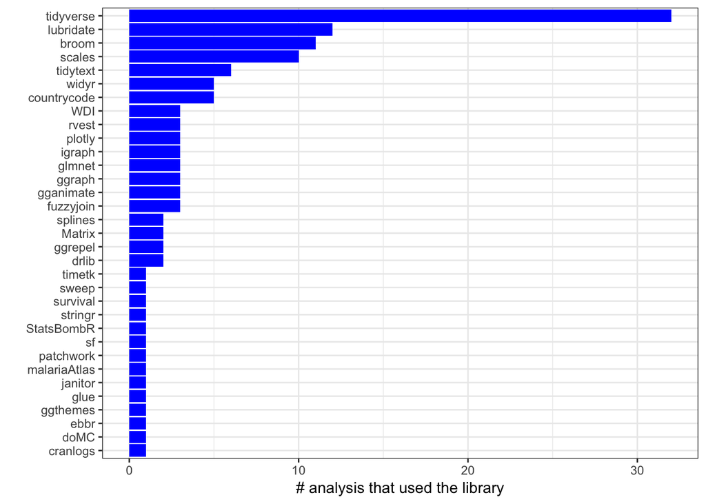

```r
ggplot(libcountdf) + geom_col(aes(x = fct_reorder(liblist, n), y = n), fill = "blue") +
  labs(x = "", y = "# analysis that used the library") + theme_bw() + coord_flip()
```

The top library as tidyverse is to be expected. It is interesting that lubridate is second. I can see that broom is used quite a bit since after exploratory analysis in the screencast, David explores some models. There are several that I was not aware of but I will probably look up the following: widyr, fuzzyjoin, glue, janitor, patchwork and the context in which they were used in the screencast.

```r
# dataframe with list of functions
fnlistdf = bind_rows(fnlistL)
fncountdf = fnlistdf %>% count(fnlist, sort = TRUE)
```

The table below lists the functions extracted from Rmd files.

```r
datatable(fncountdf)
```

|  | fnlist | n |
| --- | --- | --- |
| 1 | aes | 273 |
| 2 | mutate | 237 |
| 3 | ggplot | 223 |
| 4 | filter | 205 |
| 5 | library | 127 |
| 6 | group_by | 110 |
| 7 | labs | 110 |
| 8 | c | 80 |
| 9 | count | 80 |
| 10 | arrange | 78 |

[output cut: 294 more lines]

The current logic extracts things such as *aes*, *c*, *scale_x_continuous* which are not of interest to us here. We will combine the above data with list of functions in tidyverse packages to clean up the list of functions of interest.

```r
# get all functions in tidyverse packages
# https://stackoverflow.com/questions/8696158/find-all-functions-including-private-in-a-package/8696442#8696442
#
pkglist = tidyverse_packages()
pkglist[which(pkglist == "readxl\n(>=")] = "readxl"
pkgfunsL = list()
for(i in 1:length(pkglist)) {
  #print(i)
  pkgfuns = ls(getNamespace(pkglist[i]), all.names=TRUE)
  pkgfunsL[[i]] = tibble(pkg = pkglist[i], pkgfuns = pkgfuns)
}

pkgfunsdf = bind_rows(pkgfunsL)

# keep extracted functions that have an associated tidyverse package
fncountdf2 = inner_join(fncountdf, pkgfunsdf %>% rename(fnlist = pkgfuns), by = "fnlist")

fncountpltdf = fncountdf2 %>%
       mutate(fnlist2 = fct_reorder(fnlist, n))

# Count number of functions used in each package
pkgfncount = fncountdf2 %>% count(pkg, sort = TRUE)
```

The plot below shows the number of functions used in each package

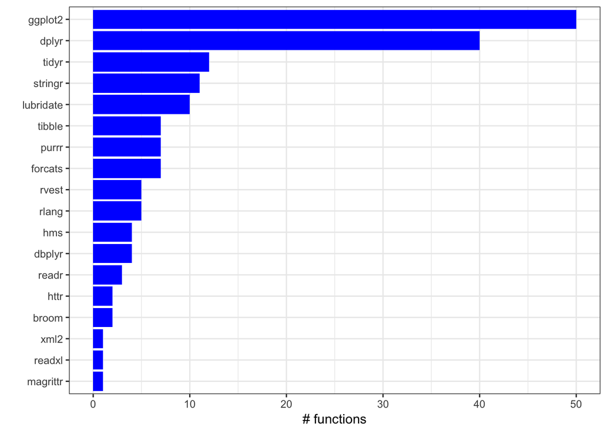

```r
ggplot(pkgfncount) + geom_col(aes(x = fct_reorder(pkg, nn), y = nn), fill = "blue") +
  labs(x = "", y = "# functions") + theme_bw() + coord_flip()
```

As expected, most used functions are from *ggplot2*, *dplyr*, *tidyr* since there is lot of exploratory analysis and visualization of data in the screencasts.

We next plot the list of functions used from each package.

```r
getplot = function(df) {
  p = ggplot() + geom_col(data = df, aes(x = fnlist2, y = n), fill = "blue")
  p = p + facet_wrap(~pkg, scales = "free") + labs(x = "", y = "")
  p = p + coord_flip() + theme_bw()
  p
}
```

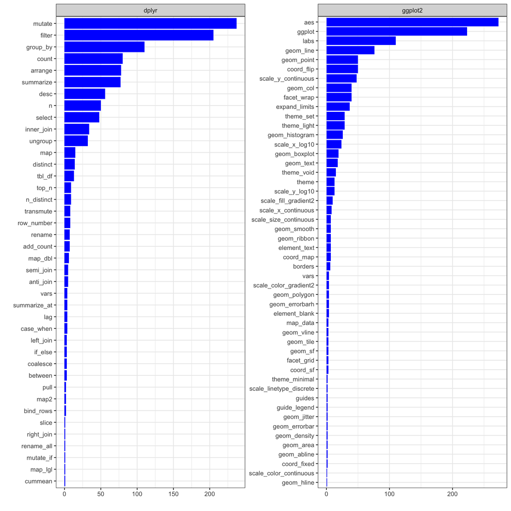

```r
getplot(fncountpltdf %>%
          filter(pkg %in% c("ggplot2", "dplyr"))
)
```

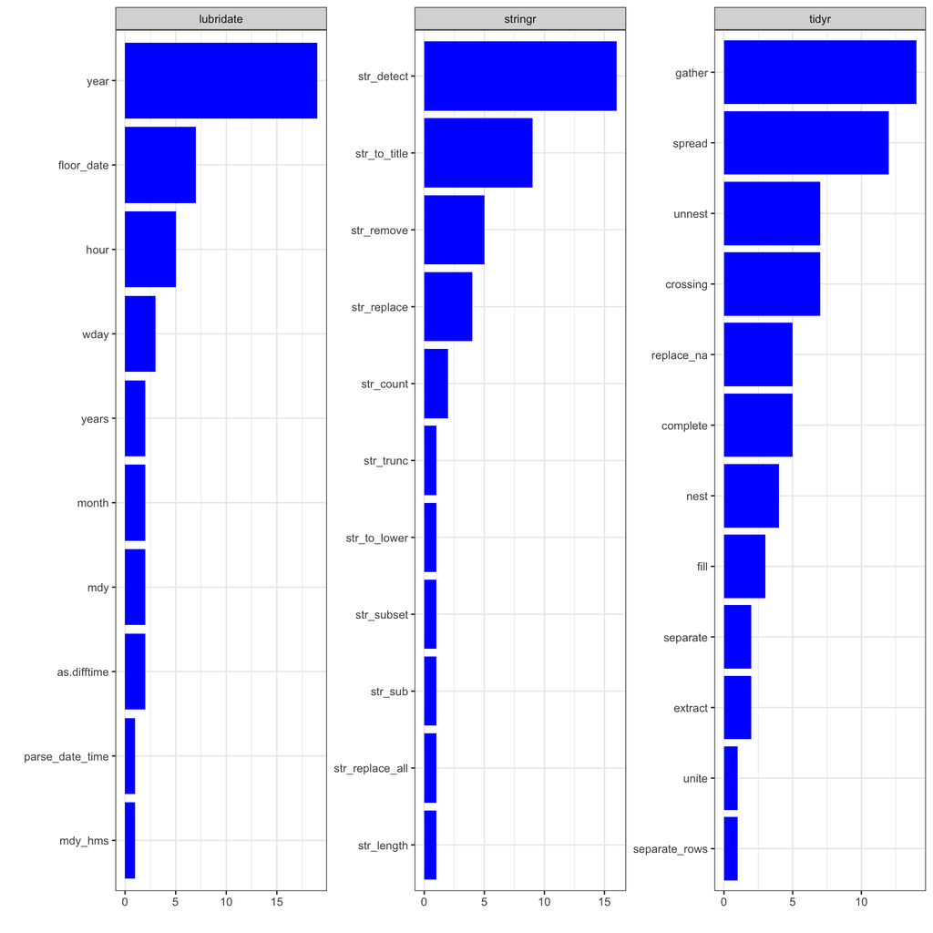

```r
getplot(fncountpltdf %>%
          filter(pkg %in% c("tidyr", "lubridate", "stringr"))
)
```

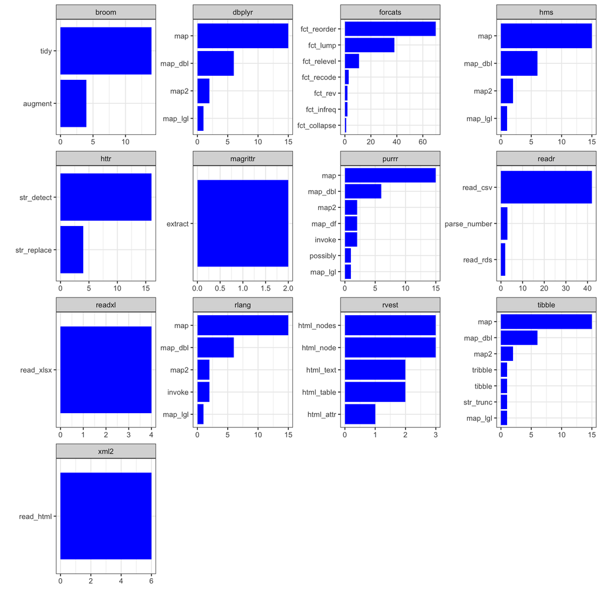

```r
getplot(fncountpltdf %>%
          filter(!(pkg %in% c("ggplot2", "dplyr", "tidyr", "lubridate", "stringr")))
)
```

Based on the above figures, I am listing below some functions that I was not aware of and should learn

- *count* function in *dplyr* as a easier way to count for each group or sum a variable for each group.
- *geom_col* function in *ggplot2* for bar graphs
- I became aware of *forcats* package for working with factors. *fct_reorder* and *fct_lump* from the package were used frequently.
- *tidyr* functions - *nest/unnest*, *crossing*, *separate_rows*
- I realized that I know only a few functions in *stringr* and should learn more about several functions that were used in the screencast.